# EnergyDataSimulationChallenge

Kiyotaka Mori

2015-07-12

This is my answer of the Github Challenge.

I used two extra packages, “ggplot2” and “dplyr”. So, if you didn’t install it, please type it without “#”.

```r
#install.packages(c("ggplot2", "dplyr"))
```

First of all, read the data(total_watt.csv).

```r
setwd("~/Desktop/analysis")
data <- read.csv("total_watt.csv", header=F)
colnames(data) <- c("time_stamp", "energy_consumption")
date <- as.POSIXlt(data$time_stamp)
data <- data.frame(date, data$energy_consumption)
colnames(data) <- c("time_stamp", "energy_consumption")
```

# Visualise the data-set

Visualise the data-set using line graph.

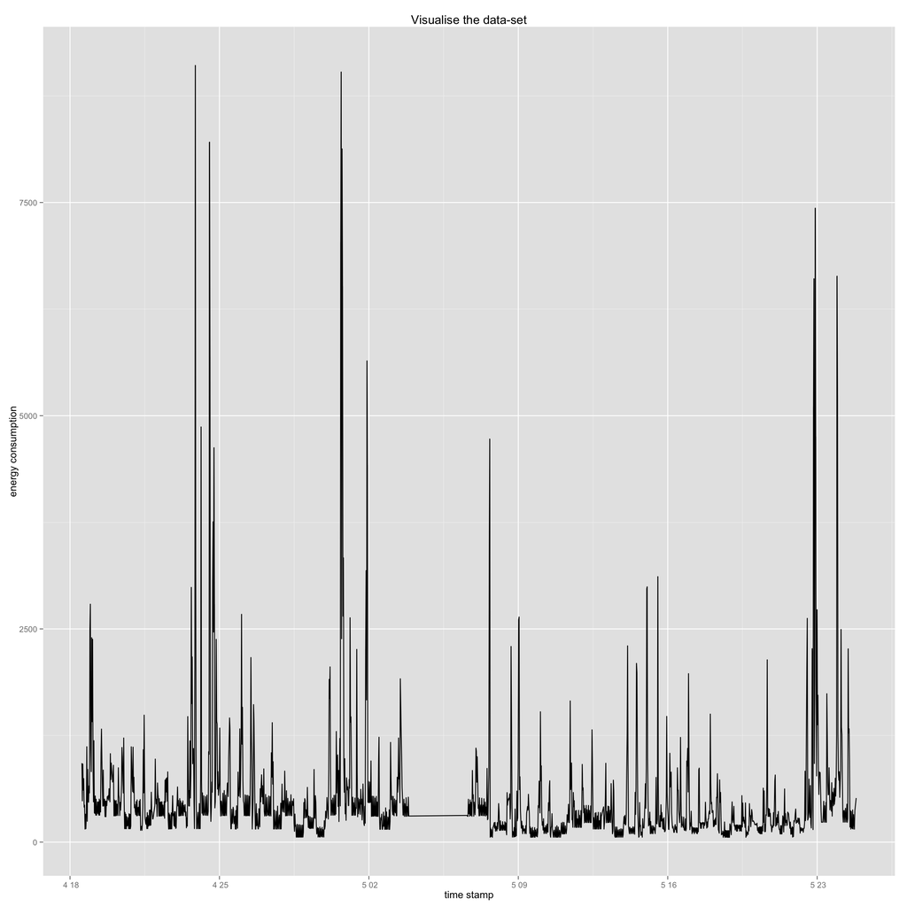

```r
library(ggplot2)
vis1 <- ggplot(data, aes(x = data$time_stamp, y = data$energy_consumption, group = 1)) + geom_line() +
xlab("time stamp") + ylab("energy consumption") + ggtitle("Visualise the data-set")

plot(vis1)
```

# Visualise the data-set as values per day

The time-stamp data is reading as string, so I change the type of it to date. The time_stamp is divided “date” and “time”.

Finally, I define four time zone.

| Time | Time zone |
| --- | --- |
| 0:00 - 6:00 | late-night |
| 6:00 - 12:00 | morning |
| 12:00 - 18:00 | afternoon |
| 18:00 - 0:00 | night |

Apply them for data.

```r
library(dplyr)
date <- format(data$time_stamp, "%m/%d")
time <- format(data$time_stamp, "%H:%M:%S")
hour <- as.numeric(format(data$time_stamp, "%H"))
data_divide <- data.frame(date, time, hour, data$energy_consumption)
colnames(data_divide) <- c("date", "time", "hour", "energy_consumption")

data_divide <- data_divide %>%
  mutate(timezone = ifelse(hour < 6, "late-night",
                           ifelse(hour < 12, "morning",
                                  ifelse(hour < 18, "afternoon",
                                         ifelse(hour < 24, "night", "other")
                                        )
                                  )
                           )
         )
data_perday <- data_divide %>% group_by(date, timezone) %>% summarise(sum=sum(energy_consumption))
```

Visualize the data per day including timezone.

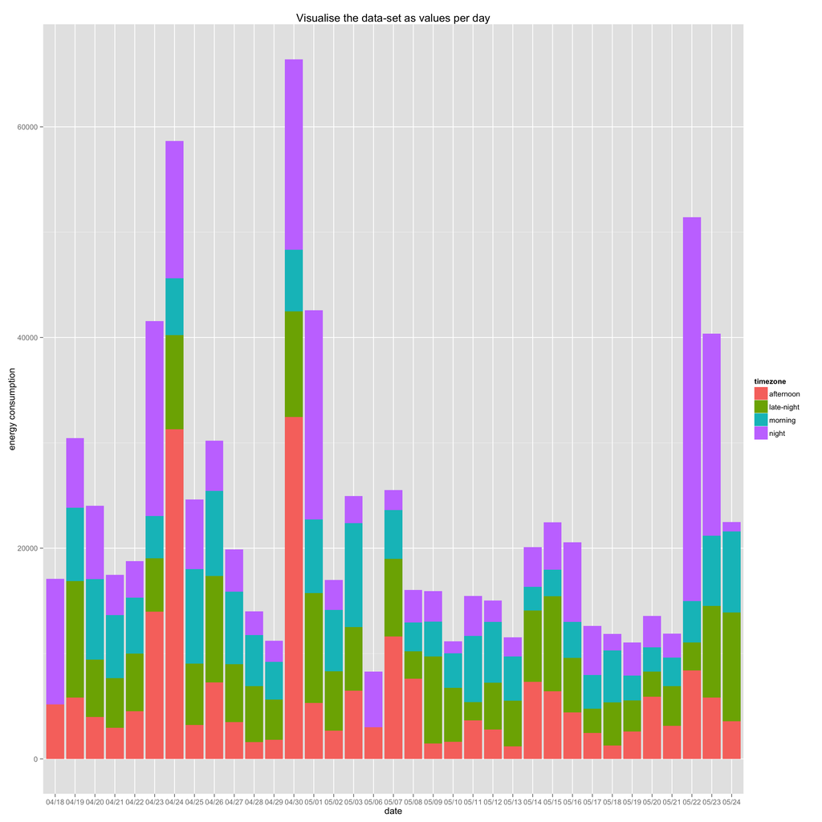

```r
vis2 <- ggplot(data_perday, aes(x = data_perday$date, y = data_perday$sum, fill=timezone)) + geom_bar(stat = "identity") +
  xlab("date") + ylab("energy consumption") + ggtitle("Visualise the data-set as values per day")

plot(vis2)
```

# Cluster the values per day into 3 groups: low, medium, and high energy consumption

Check the numbers which contains value, because want to decide the base line.

```r
data_perday2 <- data_divide %>% group_by(date) %>% summarise(sum_all=sum(energy_consumption))

sum(data_perday2$sum_all<10000)
```

```
## [1] 1
```

```r
sum(data_perday2$sum_all<20000)
```

```
## [1] 19
```

```r
sum(data_perday2$sum_all<30000)
```

```
## [1] 27
```

```r
sum(data_perday2$sum_all<40000)
```

```
## [1] 29
```

```r
sum(data_perday2$sum_all<50000)
```

```
## [1] 32
```

```r
sum(data_perday2$sum_all<60000)
```

```
## [1] 34
```

```r
sum(data_perday2$sum_all<70000)
```

```
## [1] 35
```

From these results, make three cluster.

- low (energy consumption < 20000)
- middle (20000 <= energy consumption < 40000)
- high (40000 <= energy consumption)

Apply these clusters.

```r
data_perday2 <- data_perday2 %>% mutate(cluster = ifelse(sum_all < 20000, 1,
                                                       ifelse(40000 < sum_all, 3, 2)
                                                       )
                                      )
```

# Visualise the clusters

First, I arrange the data to apply.

```r
cluster_high <- data_perday %>% inner_join(data_perday2, by="date") %>% filter(cluster == 3) %>%
  group_by(timezone) %>% summarise(sum=sum(sum))
cluster_middle <- data_perday %>% inner_join(data_perday2, by="date") %>% filter(cluster == 2) %>%
  group_by(timezone) %>% summarise(sum=sum(sum))
cluster_low <- data_perday %>% inner_join(data_perday2, by="date") %>% filter(cluster == 1) %>%
  group_by(timezone) %>% summarise(sum=sum(sum))
```

Show the pie chart of high energy consumption.

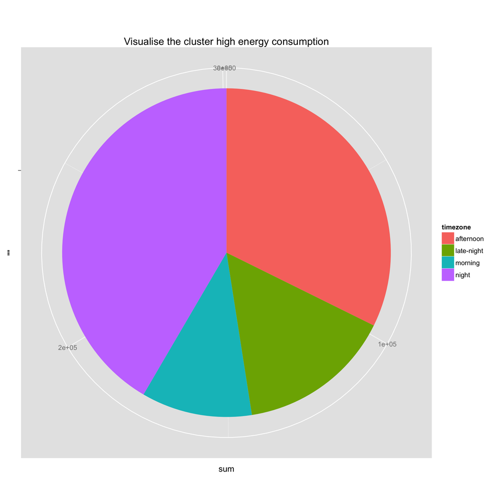

```r
vis3_1 <- ggplot(cluster_high, aes(x = "", y = sum, fill = timezone)) + geom_bar(width=1, stat="identity") +
  coord_polar(theta = "y") + ggtitle("Visualise the cluster high energy consumption")
plot(vis3_1)
```

Show the pie chart of middle energy consumption.

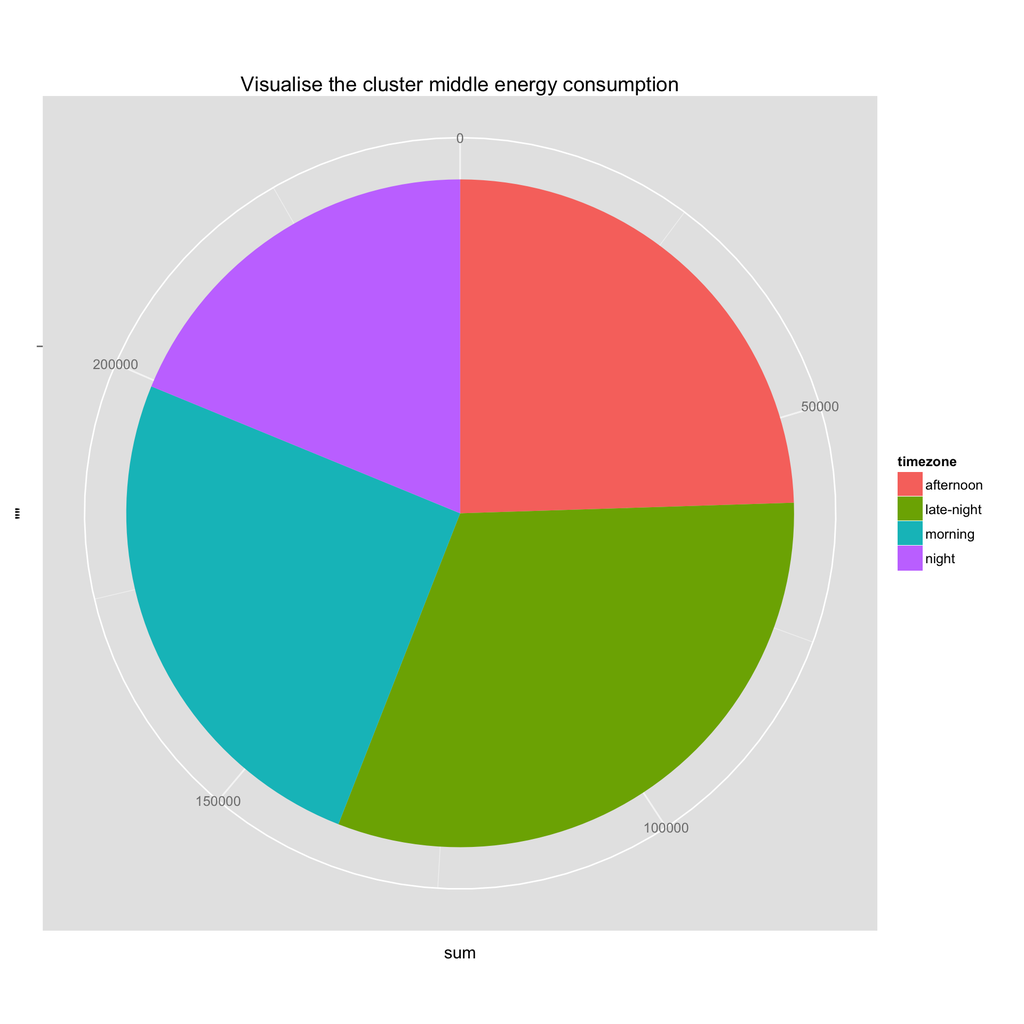

```r
vis3_2 <- ggplot(cluster_middle, aes(x = "", y = sum, fill = timezone)) + geom_bar(width=1, stat="identity") +
  coord_polar(theta = "y") + ggtitle("Visualise the cluster middle energy consumption")
plot(vis3_2)
```

Show the pie chart of low energy consumption.

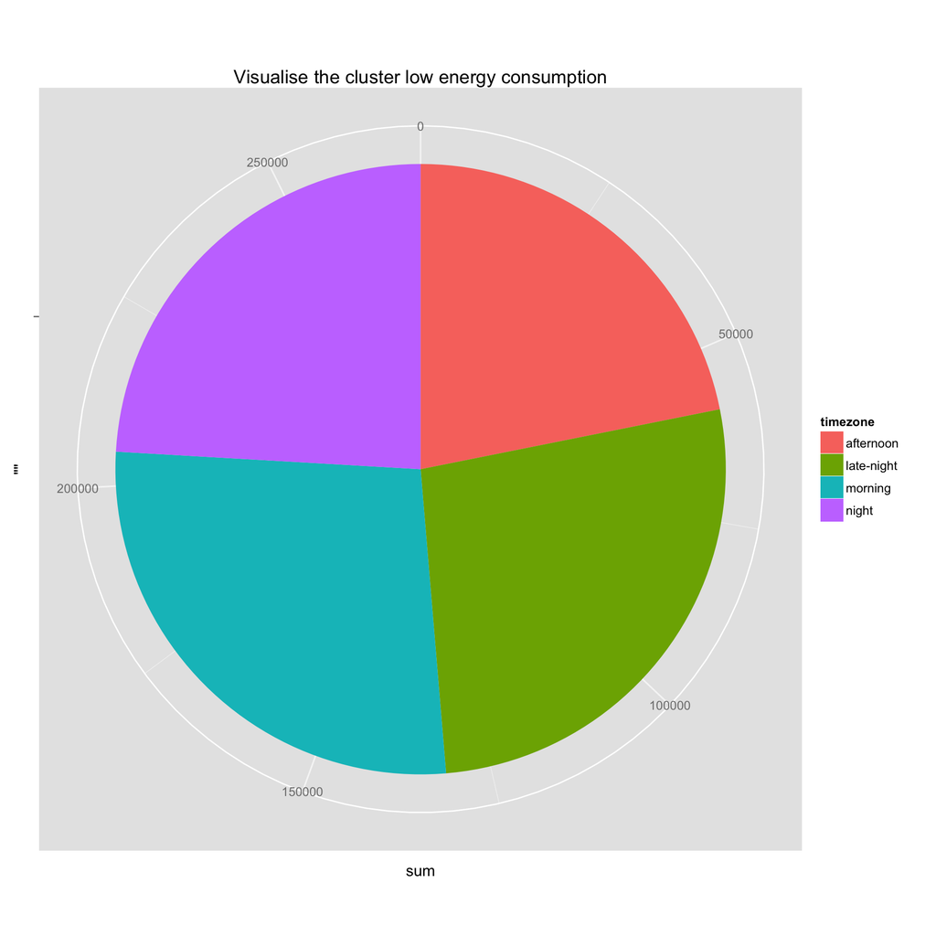

```r
vis3_3 <- ggplot(cluster_low, aes(x = "", y = sum, fill = timezone)) + geom_bar(width=1, stat="identity") +
  coord_polar(theta = "y") + ggtitle("Visualise the cluster low energy consumption")
plot(vis3_3)
```

# Addition

In this data, there are some lacking data. If I have a time, I should estimate them using time series estimation.